# Annotation_Enrichment_Functional

## QTL Enrichment using GALLO

The theory behind the QTL enrichment analysis is pretty much the same that the Gene Enrichment, but instead of testing for presence in a **GO term** we are going to test for a **specific trait**, look the scenario bellow, we tried to correlate the image with the QTL enrichment output from GALLO.

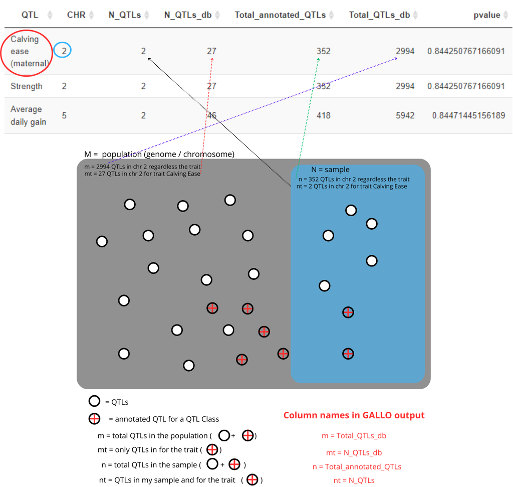

- The **red circle** is trait that is being tested for QTL enrichment
- The **blue circle** is the chromossome we are considering our “population”, but could also be for the whole genome and not for chromosome
- The **green arrow** shows the total number of QTL in chromosome 2 surrounding our significant SNP markers, this represent our sample size or **n**
- The **black arrow** show the total # of QTLs in chromosome 2 surrounding our significant SNP markers associated with a specific trait, i.e out of the **n** how many are associated to a specific trait and it is the **nt** value.
- The **purple arrow** show the total number of QTL in our population (chromossome or genome), this represents the **m** value
- The **red arrow** show the total of QTLs in chromosome 2 associated with a specific trait, i.e out of the **m** how many are associated to a specific trait and it is the **mt** value.

The probability formula is:

$$P = \frac{{\binom{mt}{nt} \cdot
\binom{m-mt}{n-nt}}}{{\binom{m}{n}}}$$

Using our example:

$$P = \frac{{\binom{27}{2} \cdot
\binom{2967}{350}}}{{\binom{2994}{352}}}$$

```r
chr_ann <- 27
sample_ann <- 2
chr_qtl <- 2994
sample_qtl <- 352
log_numerator <- lchoose(chr_ann, sample_ann) + lchoose((chr_qtl - chr_ann), (sample_qtl - sample_ann))
log_denominator <- lchoose(chr_qtl, sample_qtl)
log_P <- log_numerator - log_denominator
P <- exp(log_P)
```

But to estimate the **p-value** you need to sum up all probabilities equal or rarer, in other words I need to calculate the probabilities in the same way that in the previour formula for all situations bellow and then sum up:

> 2 QTLs out of 27 QTLs (**my sample**)  
> 3 QTLs out of 27 QTLs  
> 4 QTLs out of 27 QTLs  
> 5 QTLs out of 27 QTLs  
> .  
> .  
> .  
> 27 QTLs out of 27 QTLs

$$P = \sum_{i=2}^{27}
\frac{{\binom{mt}{nt_i} \cdot \binom{m-mt}{n-nt}}}{{\binom{m}{n}}}$$

The output of the formula above will be the p-value and can also be calculated in **r** using the code below.

```r
chr_ann <- 27 # These are the the QTLs for a specific trait annotated in a specific chromosome (mt)
chr_qtl <- 2994 # These are ALL QTLs (regardless the trait) annotated for a specific chromosome (Population size = m)
sample_qtl <- 352 # These are the SAMPLE QTLs (regardless the trait) annotated for your sample at a specific chromosome (Sample size = n)
log_denominator <- lchoose(chr_qtl, sample_qtl)

# Initialize a vector to store the results
probabilities <- numeric(26)  # We'll have 26 new combinations from 2 to 27

# Loop through different sample sizes from 2 to 27 --> these are the QTLs for a specific trait annotated in a specific chromosome for my SAMPLE (nt)
for (sample_ann in 2:27) {
  # Calculate the logarithm of the numerator
  log_numerator <- lchoose(chr_ann, sample_ann) + lchoose((chr_qtl - chr_ann), (sample_qtl - sample_ann))

  # Calculate the logarithm of P
  log_P <- log_numerator - log_denominator

  # Calculate P
  P <- exp(log_P)

  # Store the result
  probabilities[sample_ann - 1] <- P
}

# Print the probabilities
print(probabilities)

# Calculate the sum of probabilities
total_probability <- sum(probabilities)
total_probability
```

## QTL enrichment

You need to set up different parameter to check the p-value for each QTL

- qtl_db = the .gff file
- qtl_file = the first output from Gallo with the surrounding QTLs
- qtl_type = c(“QTL_type”, “trait”),
- enrich_type = c(“genome”, “chromosome”),
- chr.subset = NULL,
- nThreads = NULL,
- padj = c(“holm”, “hochberg”,“hommel”, “bonferroni”, “BH”, “BY”, “fdr”, “none”))

```r
#QTL enrichment analysis



out.enrich<-qtl_enrich(qtl_db= qtl_dbb,
                       qtl_file= out.qtl, qtl_type = "Name",
                       enrich_type = "chromosome", chr.subset = NULL,
                       padj = "fdr",nThreads = 2)
```

The output has this columns

- QTL: The QTL class or trait used for the enrichment;
- CHR: The chromosome for that specific QTL or trait (if the option “chromosome” is informed to the argument enrich_type);
- N_QTLs: Number of observed QTLs or traits in the dataset;
- N_QTLs_db: Number of each annotated QTL in the qTL database;
- Total_annotated_QTLs: Total number of annotated QTLs;
- Total_QTLs_db: Total number of QTLs in the QTL database;
- pvalue: P-value for the enrichment analysis;
- adj.pval: The adjusted p-value based on the multiple test correction selected by the user;
- QTL_type= The QTL type for each annotated trait.

## QTLenrich_plot

You need to set up the following parameters

- qtl_enrich: The output from qtl_enrich function
- x: ID column to be used from the qtl_enrich output
- pval: P-value to be used in the plot. If “p_value” informed, a non-adjusted pvalue will be plotted. If “p.adj” informed, the adjusted p-value from the qtl enrichment analysis will be plotted.

  Creating a new ID composed by the trait and the chromosome

  ```r
  out.enrich$ID<-paste(out.enrich$QTL," - ","CHR",out.enrich$CHR,sep="")
  ```

  ```r
  out.enrich.filtered<-out.enrich[which(out.enrich$adj.pval<0.05),]
  ```

  Plotting the enrichment results for the QTL enrichment analysis

  ```r
  QTLenrich_plot(out.enrich.filtered, x="ID", pval="adj.pval")
  ```

# Gene Enrichment

## GPROFILER

To perform the Gene enrichment analysis we are goint to use the application GPROFILER, you can use GPROFILER either in R or online.

```r
### enriquecimento genico
#install.packages("gprofiler2")
library(gprofiler2)

#Para conferir a lista de organism -> https://biit.cs.ut.ee/gprofiler/page/organism-list

#Obs: eu entro com os ids ENSOAR...
query <- read.table ("/out_genes_60k.txt", header = T)
query <- query[,c("gene_id")]

gene_enrich <- gost(
  query,
  organism = "chircus", #o de cabra é "chircus"
  ordered_query = FALSE,
  multi_query = FALSE,
  significant = TRUE,
  exclude_iea = FALSE,
  measure_underrepresentation = FALSE,
  evcodes = TRUE,
  user_threshold = 0.10,
  correction_method = c("fdr"),
  domain_scope = c("annotated"),
  numeric_ns = "",
  sources = NULL,
  as_short_link = FALSE,
  highlight = FALSE
)


#str(gene_enrich) # para ver o formato dos meus dados

#selecionando apenas as informações da lista que me interessam para fazer meu data.frame
result_enrich <- data.frame(gene_enrich$result)
result_enrich <- data.frame(Category = result_enrich$source,
                            ID = result_enrich$term_id,
                            Term = result_enrich$term_name,
                            adj_pvalue = result_enrich$p_value,
                            id_ensembl = result_enrich$intersection)

write.table(result_enrich,"/home/bambrozi/Sec_ARS1_GrassHill_1/GPROFILER/gene_enrich.txt", col.names=TRUE, row.names=FALSE, sep="\t", quote=F)



gostplot(
  gene_enrich,
  capped = TRUE,
  interactive = T,
  pal = c(`GO:MF` = "#dc3912", `GO:BP` = "#ff9900", `GO:CC` = "#109618", KEGG =
            "#dd4477", REAC = "#3366cc", WP = "#0099c6", TF = "#5574a6", MIRNA = "#22aa99", HPA =
            "#6633cc", CORUM = "#66aa00", HP = "#990099")
)

#to use this function to save, it is necesssary choose interactive =F in the previous step
#to use this function create a object "publish_gostplot" in the previous step.
publish_gostplot(
  gostplot_obj,
  highlight_terms = NULL,
  filename = NULL,
  width = NA,
  height = NA
)

#CREATE A TABLE

publish_gosttable(
  gene_enrich,
  highlight_terms = NULL,
  use_colors = TRUE,
  show_columns = c("source", "term_name", "term_size", "intersection_size"),
  filename = "result_table.pdf",
  ggplot = TRUE
)
```

# GENE ONTOLOGY

## amiGO / Panther

https://amigo.geneontology.org/amigo

# METABOLIC PATHWAYS

## REACTOME https://reactome.org/

# GENE NETWORKS

## STRING https://string-db.org/

## NETWORK ANALYST https://www.networkanalyst.ca/